# What makes a song popular?

Most people listen to music in some form. It can range from hearing a catchy tune while at a grocery store, to having a devoted playlist for every emotion possibly felt throughout your day. But what makes a song widely enjoyable to a larger audience of people? What exactly makes a song popular? Imagine you are an artist trying to make the next biggest hit, and the goal is for your next song to make it to the Billboard End of the Year list. This exploratory data analysis will attempt to answer for what makes a song popular, and provide some insights for the hypothetical artist on the qualities of a popular song so they are better equipt to make the next best hit.

```python
import numpy as np
```

```python
import spotipy
import sys
import pandas as pd
from spotipy.oauth2 import SpotifyClientCredentials

spotify = spotipy.Spotify(auth_manager=SpotifyClientCredentials(client_id=SPOTIPY_CLIENT_ID, client_secret=SPOTIPY_CLIENT_SECRET))
```

```python
df = pd.DataFrame()
for i in range(2008,2022):
  df2 = pd.read_html('https://en.wikipedia.org/wiki/Billboard_Year-End_Hot_100_singles_of_'+str(i))[0]
  df2['year'] = i
  df = df.append(df2, ignore_index=True)
```

```python
df.head()
```

|  | № | Title | Artist(s) | year | No. | 0 | 1 |
| --- | --- | --- | --- | --- | --- | --- | --- |
| 0 | 1.0 | "Low" | Flo Rida featuring T-Pain | 2008 | NaN | NaN | NaN |
| 1 | 2.0 | "Bleeding Love" | Leona Lewis | 2008 | NaN | NaN | NaN |
| 2 | 3.0 | "No One" | Alicia Keys | 2008 | NaN | NaN | NaN |
| 3 | 4.0 | "Lollipop" | Lil Wayne featuring Static Major | 2008 | NaN | NaN | NaN |
| 4 | 5.0 | "Apologize" | OneRepublic | 2008 | NaN | NaN | NaN |

The columns are looking a bit wonky since we are scraping from a wide range of years. The following code will clean it up while retaining the structure of the existing data.

```python
#there appears to be no info in col2
df[df[0].isnull() == False]
```

|  | № | Title | Artist(s) | year | No. | 0 | 1 |
| --- | --- | --- | --- | --- | --- | --- | --- |

```python
df[df[1].isnull() == False]
```

|  | № | Title | Artist(s) | year | No. | 0 | 1 |
| --- | --- | --- | --- | --- | --- | --- | --- |
| 400 | NaN | NaN | NaN | 2012 | NaN | NaN | This article relies excessively on references ... |
| 401 | NaN | NaN | NaN | 2013 | NaN | NaN | This article relies excessively on references ... |

From here, it seems apparent that this is the result of a parsing error, particularly in the years 2012 and 2013, as songs from that year haven't made it to the dataframe

```python
df[(df['year'] == 2012) | (df['year'] == 2013)]
```

|  | № | Title | Artist(s) | year | No. | 0 | 1 |
| --- | --- | --- | --- | --- | --- | --- | --- |
| 400 | NaN | NaN | NaN | 2012 | NaN | NaN | This article relies excessively on references ... |
| 401 | NaN | NaN | NaN | 2013 | NaN | NaN | This article relies excessively on references ... |

```python
df.drop([400, 401], inplace=True) #drop the row
```

```python
df2 = pd.read_html('https://en.wikipedia.org/wiki/Billboard_Year-End_Hot_100_singles_of_'+str(2012))[1]
df2['year'] = 2012
df = df.append(df2)
df2 = pd.read_html('https://en.wikipedia.org/wiki/Billboard_Year-End_Hot_100_singles_of_'+str(2013))[1]
df2['year'] = 2013
df = df.append(df2)
```

Clean up! There is an № and No. We will merge those, and remove the 0 and 1 cols. In addition remove any duplicates, as a song can reach the end of year list 2+ times

```python
df.drop(columns=[0,1], inplace=True) #since these two columns in particular are a result of a parsing error
df['No.']=df['No.'].fillna(df['№']) #shift the values where ranking number is №
df.drop(columns=['№'], inplace=True)
df.dropna(inplace=True)
df.drop_duplicates(subset=['Title','Artist(s)'], inplace=True) #since songs can appear twice in this list
df
```

|  | Title | Artist(s) | year | No. |
| --- | --- | --- | --- | --- |
| 0 | "Low" | Flo Rida featuring T-Pain | 2008 | 1.0 |
| 1 | "Bleeding Love" | Leona Lewis | 2008 | 2.0 |
| 2 | "No One" | Alicia Keys | 2008 | 3.0 |
| 3 | "Lollipop" | Lil Wayne featuring Static Major | 2008 | 4.0 |
| 4 | "Apologize" | OneRepublic | 2008 | 5.0 |
| ... | ... | ... | ... | ... |
| 93 | "Get Your Shine On" | Florida Georgia Line | 2013 | 94.0 |
| 94 | "#thatPower" | will.i.am featuring Justin Bieber | 2013 | 95.0 |
| 97 | "Runnin' Outta Moonlight" | Randy Houser | 2013 | 98.0 |
| 98 | "I'm Different" | 2 Chainz | 2013 | 99.0 |
| 99 | "Still Into You" | Paramore | 2013 | 100.0 |

1262 rows × 4 columns

Using the search feature in the spotify api can return a lot of information about a given track, such as countries where it is available, all associated artists and links to their profile on spotify, popularity ranking, etc. Because of this we will now use the spotify search to get trackids and artistids. We can use the artist id to get the genre,and the track id to get features present within the actual song, such as "danceability" and "energy". Since we are searching by keyword, this can make the search results prone to errors, especially in a larger dataset like this (i.e. getting a live, acoustic, remix version of the original song we are searching for).

We cannot completely filter out remixes, as sometimes the remixes are what is more popular (i.e. Finesse Remix Bruno Mars ft. Cardi B). Therefore we will have a marker denoting whether the song is a remix for manual inspection. We will also search songs that have words such as 'Instrumental', 'Live', and 'Acoustic'. This won't completely filter out false search results, so in addition we will have a low popularity marker if the track popularity score is less than 40. A lower popularity score would increase the likelihood for a false search result, as all of the songs we are searching should in theory would have a higher popularity score.

Finally we will parse the artist by only focusing on the main artist (if there is a feature/other people in the track)

```python
def parse_artist(content):
    for split_token in [" & ", " \\ ", " feat ", " featuring ", " and "]:
        content = content.partition(split_token)[0]
    return content
```

Through this we can minimize the false results we will get when searching. We have empty lists which we will aggregate with values for each call to the Spotify API

```python
low_pop = []
check = []
remix = []
```

```python
track_ids = []
artist_ids = []
amt_features = [] #see how many features are in a given track
```

Now we use the spotify api to search

```python
for row in df.iterrows():
    search = "%20track:" +row[1][0].replace("\"", "") + "%20artists:" + parse_artist(row[1][1]) #search term
    results = spotify.search(q=search,type='track', limit=2) #api call

    items = results['tracks']['items']
    if len(items) > 0:
        name = items[0]['name']
        #print(name)
        track_ids.append(items[0]['id'])
        artist_ids.append(items[0]['artists'][0]['id'])
        amt_features.append(len(items[0]['artists']) - 1)

        if "remix" in name.lower():
            remix.append(name)
        else:
            remix.append(np.nan)

        if items[0]['popularity'] < 40:
            low_pop.append(name + ": " + str(items[0]['popularity']))
        else:
            low_pop.append(np.nan)

        if "instrumental" in name.lower() or "acoustic" in name.lower() or ("live" in name.lower() and "live" not in row[1][0].lower()):
            check.append(name)
        else:
            check.append(np.nan)
    else: #if search yielded no results
        track_ids.append(np.nan)
        artist_ids.append(np.nan)
        amt_features.append(np.nan)
        check.append(np.nan)
        low_pop.append(np.nan)
        remix.append(np.nan)
```

After running Spotify's API, we can add the lists to the dataframe

```python
df['track_ids'] = track_ids
df['artist_ids'] = artist_ids
df['amt_features'] = amt_features
df['check'] = check
df['low_popularity'] = low_pop
df['remix'] = remix
```

Now we have track ids and artist ids for each song. In addition, when searching for an artist, it would return a list of artists rather than a singular artist due to features and collaborations. I took the length of that list, and made a count for amount of features for each track.

```python
df.head()
```

|  | Title | Artist(s) | year | No. | track_ids | artist_ids | amt_features | check | low_popularity | remix |
| --- | --- | --- | --- | --- | --- | --- | --- | --- | --- | --- |
| 0 | "Low" | Flo Rida featuring T-Pain | 2008 | 1.0 | 0CAfXk7DXMnon4gLudAp7J | 0jnsk9HBra6NMjO2oANoPY | 1.0 | NaN | NaN | NaN |
| 1 | "Bleeding Love" | Leona Lewis | 2008 | 2.0 | 7wZUrN8oemZfsEd1CGkbXE | 5lKZWd6HiSCLfnDGrq9RAm | 0.0 | NaN | NaN | NaN |
| 2 | "No One" | Alicia Keys | 2008 | 3.0 | 6IwKcFdiRQZOWeYNhUiWIv | 3DiDSECUqqY1AuBP8qtaIa | 0.0 | NaN | NaN | NaN |
| 3 | "Lollipop" | Lil Wayne featuring Static Major | 2008 | 4.0 | 4P7VFiaZb3xrXoqGwZXC3J | 55Aa2cqylxrFIXC767Z865 | 1.0 | NaN | NaN | NaN |
| 4 | "Apologize" | OneRepublic | 2008 | 5.0 | 1NrJYpdAi7uosDRPmSYrsG | 5Pwc4xIPtQLFEnJriah9YJ | 0.0 | NaN | NaN | NaN |

First we need to check for the ids that yielded no results in the search.

```python
df2 = df[df.track_ids.isnull()]
df2
```

|  | Title | Artist(s) | year | No. | track_ids | artist_ids | amt_features | check | low_popularity | remix |
| --- | --- | --- | --- | --- | --- | --- | --- | --- | --- | --- |
| 59 | "Say" | John Mayer | 2008 | 60.0 | NaN | NaN | NaN | NaN | NaN | NaN |
| 200 | "Tik Tok" | Kesha | 2010 | 1.0 | NaN | NaN | NaN | NaN | NaN | NaN |
| 635 | "Broccoli" | DRAM featuring Lil Yachty | 2016 | 34.0 | NaN | NaN | NaN | NaN | NaN | NaN |
| 659 | "Starboy" | The Weeknd featuring Daft Punk | 2016 | 58.0 | NaN | NaN | NaN | NaN | NaN | NaN |
| 662 | "In the Night" | The Weeknd | 2016 | 61.0 | NaN | NaN | NaN | NaN | NaN | NaN |
| 945 | "Mia" | Bad Bunny featuring Drake | 2019 | 44.0 | NaN | NaN | NaN | NaN | NaN | NaN |
| 1129 | "Dakiti" | Bad Bunny and Jhay Cortez | 2021 | 28.0 | NaN | NaN | NaN | NaN | NaN | NaN |
| 1184 | "Yonaguni" | Bad Bunny | 2021 | 83.0 | NaN | NaN | NaN | NaN | NaN | NaN |
| 52 | "Try" | Pink | 2013 | 53.0 | NaN | NaN | NaN | NaN | NaN | NaN |

I will use a different search format to make sure there are results populated in this present search

```python
def search2(dataframe):
    ids = []
    artist_ids = []
    check = [] #I will add all song titles to check as a sanity check
    amt_features = []
    for row in dataframe.iterrows():
        search = row[1][0].replace("\"", "") + " " + parse_artist(row[1][1])
        results = spotify.search(q=search,type='track', limit=1)
        res = results['tracks']['items']
        if len(res) == 0:
            ids.append(np.nan)
            check.append(np.nan)
            artist_ids.append(np.nan)
            amt_features.append(np.nan)
        else:
            ids.append(res[0]['id'])
            check.append(res[0]['name'])
            artist_ids.append(res[0]['artists'][0]['id'])
            amt_features.append(len(res[0]['artists']) - 1)
    dataframe['track_ids'] = ids
    dataframe['artist_ids'] = artist_ids
    dataframe['check'] = check
    dataframe['amt_features'] = amt_features
```

```python
search2(df2)
```

```python
df2
```

|  | Title | Artist(s) | year | No. | track_ids | artist_ids | amt_features | check | low_popularity | remix |
| --- | --- | --- | --- | --- | --- | --- | --- | --- | --- | --- |
| 59 | "Say" | John Mayer | 2008 | 60.0 | 6wZI4mdT8JwXgkGURnBQiq | 0hEurMDQu99nJRq8pTxO14 | 0 | Say | NaN | NaN |
| 200 | "Tik Tok" | Kesha | 2010 | 1.0 | 0HPD5WQqrq7wPWR7P7Dw1i | 6LqNN22kT3074XbTVUrhzX | 0 | TiK ToK | NaN | NaN |
| 635 | "Broccoli" | DRAM featuring Lil Yachty | 2016 | 34.0 | 0qy5D3OJre7SPJNMOL9I71 | 5M0lbkGluOPXLeFjApw8r8 | 1 | Broccoli | NaN | NaN |
| 659 | "Starboy" | The Weeknd featuring Daft Punk | 2016 | 58.0 | 7MXVkk9YMctZqd1Srtv4MB | 1Xyo4u8uXC1ZmMpatF05PJ | 1 | Starboy | NaN | NaN |
| 662 | "In the Night" | The Weeknd | 2016 | 61.0 | 25KybV9BOUlvcnv7nN3Pyo | 1Xyo4u8uXC1ZmMpatF05PJ | 0 | In The Night | NaN | NaN |
| 945 | "Mia" | Bad Bunny featuring Drake | 2019 | 44.0 | 116H0KvKr2Zl4RPuVBruDO | 4q3ewBCX7sLwd24euuV69X | 1 | MIA (feat. Drake) | NaN | NaN |
| 1129 | "Dakiti" | Bad Bunny and Jhay Cortez | 2021 | 28.0 | 47EiUVwUp4C9fGccaPuUCS | 4q3ewBCX7sLwd24euuV69X | 1 | DÁKITI | NaN | NaN |
| 1184 | "Yonaguni" | Bad Bunny | 2021 | 83.0 | 2JPLbjOn0wPCngEot2STUS | 4q3ewBCX7sLwd24euuV69X | 0 | Yonaguni | NaN | NaN |
| 52 | "Try" | Pink | 2013 | 53.0 | 6TARzEGGDNSHXW3ckv2KuL | 5i0O6tyJDlb7ADVL0W7eeT | 0 | Try - Pink Cover | NaN | NaN |

Try by pink is a cover (likely because in Spotify, her name is P!nk), so I'll manually search for the track and artistID (code not shown), and merge the results to this dataframe with the original dataframe. With this we have all track ids and artist ids filled in.

```python
df4 = df.merge(df2,how="left",on=["Title", "Artist(s)", "year", "No.", "remix"])
df4['artist_ids_x'] = df4['artist_ids_x'].fillna(df4['artist_ids_y'])
df4['track_ids_x'] = df4['track_ids_x'].fillna(df4['track_ids_y'])
df4['amt_features_x'] = df4['amt_features_x'].fillna(df4['amt_features_y'])
```

```python
df4.drop(columns=["track_ids_y","artist_ids_y","amt_features_y", "check_y",	"low_popularity_y"], inplace=True)
```

Now we have no more empty ids/artists

```python
df4[df4.artist_ids_x.isnull() | df4.track_ids_x.isnull()]
```

|  | Title | Artist(s) | year | No. | track_ids_x | artist_ids_x | amt_features_x | check_x | low_popularity_x | remix |
| --- | --- | --- | --- | --- | --- | --- | --- | --- | --- | --- |

While all of the artists and tracks are filled in, not all of them are accurate. Now we'll check the remixes, low popularity tracks, and those that otherwise need to be checked in a separate dataframe. While the performances are often the same, we are later going to extract features from each of the songs, so it is imperative that the ids are reflective of the original song, and not any alternative versions as that can immpact the analysis. For instance, one of the spotify features includes "instrumentalness". If that is in our data analysis it could artificially skew our data such that there may be higher instrumentalism than there actually is in music.

We check for whether the check column (which shows whether the search result name has any keys that may indicate an alternative form of the song) is not null, whether something is a remix and if so the name of the song, and if the song has a lower popularity.

```python
df3 = df[(df.check.isnull() == False) | (df.low_popularity.isnull() == False) | (df.remix.isnull() == False)]
df3
```

|  | Title | Artist(s) | year | No. | track_ids | artist_ids | amt_features | check | low_popularity | remix |
| --- | --- | --- | --- | --- | --- | --- | --- | --- | --- | --- |
| 47 | "Teardrops on My Guitar" | Taylor Swift | 2008 | 48.0 | 7zMcNqs55Mxer82bvZFkpg | 06HL4z0CvFAxyc27GXpf02 | 0.0 | NaN | NaN | Teardrops On My Guitar - Radio Single Remix |
| 49 | "Sexual Eruption" | Snoop Dogg | 2008 | 50.0 | 3nTHTulZtTJoM3cBJTuHrJ | 7hJcb9fa4alzcOq3EaNPoG | 0.0 | NaN | Sexual Eruption: 39 | NaN |
| 101 | "Poker Face" | Lady Gaga | 2009 | 2.0 | 48Vua7xS3Wx7KpDkuRHg9g | 1HY2Jd0NmPuamShAr6KMms | 0.0 | Poker Face - Live at The Cherrytree House Pian... | Poker Face - Live at The Cherrytree House Pian... | NaN |
| 127 | "Day 'n' Nite" | Kid Cudi | 2009 | 28.0 | 6ouTGbETM7ZdID1eMXZJde | 0fA0VVWsXO9YnASrzqfmYu | 1.0 | NaN | NaN | Day 'N' Nite - Crookers Remix |
| 129 | "Don't Trust Me" | 3OH!3 | 2009 | 30.0 | 3bsDo5vjjJI7O8VuytGIrc | 0FWzNDaEu9jdgcYTbcOa4F | 0.0 | NaN | Don't Trust Me: 38 | NaN |
| ... | ... | ... | ... | ... | ... | ... | ... | ... | ... | ... |
| 80 | "50 Ways to Say Goodbye" | Train | 2012 | 81.0 | 7yDk2nHOxkrsrFyNVKp5aO | 72anORkQ1Vf7j1LedlMVHj | 0.0 | NaN | 50 Ways to Say Goodbye (Tribute to Train): 0 | NaN |
| 84 | "Die Young" | Kesha | 2012 | 85.0 | 0jdG1iWjXoflspU3IExAwe | 6LqNN22kT3074XbTVUrhzX | 3.0 | NaN | NaN | Die Young REMIX (feat. Juicy J, Wiz Khalifa & ... |
| 89 | "We Run the Night" | Havana Brown featuring Pitbull | 2012 | 90.0 | 33tORbMH4bNhiDVKUGbqEF | 1EVWYRr2obCRDoSoD6KSuM | 1.0 | NaN | We Run The Night - Edited: 29 | NaN |
| 4 | "Can't Hold Us" | Macklemore & Ryan Lewis featuring Ray Dalton | 2013 | 5.0 | 4FQDZwcvvXpqpPMquZ6qTV | 5BcAKTbp20cv7tC5VqPFoC | 1.0 | Can't Hold Us - Live From Spotify NYC feat. Ra... | NaN | NaN |
| 75 | "Carry On" | Fun | 2013 | 76.0 | 7sJBr9jSf1SJ3ls0bi134Z | 7su6ew3HCRmlQpmkYIEsgt | 0.0 | NaN | Carry On: 35 | NaN |

82 rows × 10 columns

We can see the alternative songs (check) here:

```python
df[df.check.isnull() == False]['check']
```

```
101     Poker Face - Live at The Cherrytree House Pian...
180                                  Chicken Fried - Live
370     Yoü And I - Live from "A Very Gaga Thanksgiving'"
426                    Chandelier - Live from The Village
515          Take Me to Church - Live From Spotify London
535                       Photograph (Instrumental Piano)
695                                   Starving - Acoustic
705     Humble (Originally Performed by Kendrick Lamar...
839     Ric Flair Drip (Originally Performed by Offset...
928     Someone You Loved - Live from Capitol Studios ...
947                            Beautiful Crazy - Acoustic
963                                Circles - Instrumental
1053       Nobody But You (Duet with Gwen Stefani) - Live
1087    The Scotts (Originally Performed by The Scotts...
1151    Whoopty (Originally Performed by CJ) [Instrume...
1152            Lemonade (feat. Gunna, Don Toliver & NAV)
1187    Knife Talk (Originally Performed by Drake, 21 ...
39      Niggas In Paris (Remade Instrumental Originall...
4       Can't Hold Us - Live From Spotify NYC feat. Ra...
Name: check, dtype: object
```

We can also analyze the remixes

```python
df[df.remix.isnull() == False]['remix']
```

```
47            Teardrops On My Guitar - Radio Single Remix
127                         Day 'N' Nite - Crookers Remix
185                  How Do You Sleep? - Radio Edit Remix
353                            Stereo Love - Twelve Remix
360                       More - RedOne Jimmy Joker Remix
413                                Pompeii - Audien Remix
433            Habits (Stay High) - Hippie Sabotage Remix
469                                    Bottoms Up - Remix
510     Earned It (Fifty Shades Of Grey) - Marian Hill...
512        Cheerleader Tribute to Felix Jaehn Remix (OMI)
533     GDFR (feat. Sage the Gemini & Lookas) - K Theo...
539                                       Jealous - Remix
573            Classic Man (feat. Kendrick Lamar) - Remix
579                        The Hanging Tree - Rebel Remix
603                                  Sorry - Latino Remix
```

[output cut: 26 more lines]

Now if we analyze remixes, a lot of the remixes, including

- Teardrops on my Guitar
- Finesse
- Dance A$$
- I took a Pill in Ibiza
- Plain Jane
- Shotta Flow
- 34 + 35
- Old Town Road
- Suicidal
- Savage
- What's Poppin
- Save Your Tears

They can be removed from the dataframe, so we don't have to search again with those.

```python
df3.drop([56,1122,1103,1076,1016,1014,993,902,875, 815,616, 47], inplace=True)
```

Now that I've removed all of the remixes that do not need to be searched, we run search2 on the new dataframe (again with the new names in the check column to manually check if the results are accurate). After manually tuning some of the final values (not shown), merge it with the main df

```python
search2(df3)
```

```python
df3.head(10)
```

|  | Title | Artist(s) | year | No. | track_ids | artist_ids | amt_features | check | low_popularity | remix |
| --- | --- | --- | --- | --- | --- | --- | --- | --- | --- | --- |
| 49 | "Sexual Eruption" | Snoop Dogg | 2008 | 50.0 | 3nTHTulZtTJoM3cBJTuHrJ | 7hJcb9fa4alzcOq3EaNPoG | 0 | Sexual Eruption | Sexual Eruption: 39 | NaN |
| 101 | "Poker Face" | Lady Gaga | 2009 | 2.0 | 5R8dQOPq8haW94K7mgERlO | 1HY2Jd0NmPuamShAr6KMms | 0 | Poker Face | Poker Face - Live at The Cherrytree House Pian... | NaN |
| 127 | "Day 'n' Nite" | Kid Cudi | 2009 | 28.0 | 5wfllwdjglyQislkskYLBv | 0fA0VVWsXO9YnASrzqfmYu | 0 | Day 'N' Nite (nightmare) | NaN | Day 'N' Nite - Crookers Remix |
| 129 | "Don't Trust Me" | 3OH!3 | 2009 | 30.0 | 5jzX4dWVQeBTtfBaXnMRt5 | 0FWzNDaEu9jdgcYTbcOa4F | 0 | DONTTRUSTME | Don't Trust Me: 38 | NaN |
| 180 | "Chicken Fried" | Zac Brown Band | 2009 | 81.0 | 0LQtEJt7x0s6knb6RKdRYc | 6yJCxee7QumYr820xdIsjo | 0 | Chicken Fried | Chicken Fried - Live: 30 | NaN |
| 185 | "How Do You Sleep?" | Jesse McCartney featuring Ludacris | 2009 | 86.0 | 3jkdQNkDTxxXtjSO4l0o1H | 2Hjj68yyUPiC0HKEOigcEp | 1 | How Do You Sleep? - Radio Edit Remix | NaN | How Do You Sleep? - Radio Edit Remix |
| 187 | "Forever" | Drake featuring Kanye West, Lil Wayne and Eminem | 2009 | 88.0 | 5UsLjwBaTHBX4ektWIr4XX | 3TVXtAsR1Inumwj472S9r4 | 3 | Forever | Forever - Album Version (Edited): 36 | NaN |
| 280 | "Stuck Like Glue" | Sugarland | 2010 | 81.0 | 0JcKdUGNR7zI4jJDLyYXbi | 0hYxQe3AK5jBPCr5MumLHD | 0 | Stuck Like Glue | Stuck Like Glue (A Tribute To Sugarland): 0 | NaN |
| 290 | "The House That Built Me" | Miranda Lambert | 2010 | 91.0 | 02eD9ymfJOJOhM97HYp5R9 | 66lH4jAE7pqPlOlzUKbwA0 | 0 | The House That Built Me | The House That Built Me (As Made Famous By Mir... | NaN |
| 291 | "If I Die Young" | The Band Perry | 2010 | 92.0 | 4u26EevCNXMhlvE1xFBJwX | 75FnCoo4FBxH5K1Rrx0k5A | 0 | If I Die Young | If I Die Young: 29 | NaN |

```python
df5 = df4.merge(df3,how="left",on=["Title", "Artist(s)", "year", "No.", "remix"])
```

```python
df5.head()
```

|  | Title | Artist(s) | year | No. | track_ids_x | artist_ids_x | amt_features_x | check_x | low_popularity_x | remix | track_ids | artist_ids | amt_features | check | low_popularity |
| --- | --- | --- | --- | --- | --- | --- | --- | --- | --- | --- | --- | --- | --- | --- | --- |
| 0 | "Low" | Flo Rida featuring T-Pain | 2008 | 1.0 | 0CAfXk7DXMnon4gLudAp7J | 0jnsk9HBra6NMjO2oANoPY | 1.0 | NaN | NaN | NaN | 0CAfXk7DXMnon4gLudAp7J | 0jnsk9HBra6NMjO2oANoPY | 1.0 | NaN | NaN |
| 1 | "Bleeding Love" | Leona Lewis | 2008 | 2.0 | 7wZUrN8oemZfsEd1CGkbXE | 5lKZWd6HiSCLfnDGrq9RAm | 0.0 | NaN | NaN | NaN | 7wZUrN8oemZfsEd1CGkbXE | 5lKZWd6HiSCLfnDGrq9RAm | 0.0 | NaN | NaN |
| 2 | "No One" | Alicia Keys | 2008 | 3.0 | 6IwKcFdiRQZOWeYNhUiWIv | 3DiDSECUqqY1AuBP8qtaIa | 0.0 | NaN | NaN | NaN | 6IwKcFdiRQZOWeYNhUiWIv | 3DiDSECUqqY1AuBP8qtaIa | 0.0 | NaN | NaN |
| 3 | "Lollipop" | Lil Wayne featuring Static Major | 2008 | 4.0 | 4P7VFiaZb3xrXoqGwZXC3J | 55Aa2cqylxrFIXC767Z865 | 1.0 | NaN | NaN | NaN | 4P7VFiaZb3xrXoqGwZXC3J | 55Aa2cqylxrFIXC767Z865 | 1.0 | NaN | NaN |
| 4 | "Apologize" | OneRepublic | 2008 | 5.0 | 1NrJYpdAi7uosDRPmSYrsG | 5Pwc4xIPtQLFEnJriah9YJ | 0.0 | NaN | NaN | NaN | 1NrJYpdAi7uosDRPmSYrsG | 5Pwc4xIPtQLFEnJriah9YJ | 0.0 | NaN | NaN |

We will replace the wrong ids with the new correct ids

```python
df5['artist_ids'] = df5['artist_ids'].fillna(df5['artist_ids_x'])
df5['track_ids'] = df5['track_ids'].fillna(df5['track_ids_x'])
df5['amt_features'] = df5['amt_features'].fillna(df5['amt_features_x'])
```

```python
frame = df5.filter(items=['Title', 'Artist(s)', 'year', 'No.', 'track_ids', 'artist_ids', 'amt_features'])
```

We now populated the dataframe with clean and accurate data.

```python
frame.head()
```

[output not shown]

Now that we have the complete dataframe with the accurate artistIDs and trackIDs, we can extract different features of the song with the Spotify API. For instance, here is an analysis of Low by Flo Rida and T-Pain:

```python
spotify.audio_features(tracks = ['0CAfXk7DXMnon4gLudAp7J'])
```

```
[{'danceability': 0.918,
  'energy': 0.609,
  'key': 10,
  'loudness': -5.64,
  'mode': 0,
  'speechiness': 0.0791,
  'acousticness': 0.0928,
  'instrumentalness': 0,
  'liveness': 0.139,
  'valence': 0.304,
  'tempo': 128.008,
  'type': 'audio_features',
  'id': '0CAfXk7DXMnon4gLudAp7J',
  'uri': 'spotify:track:0CAfXk7DXMnon4gLudAp7J',
  'track_href': 'https://api.spotify.com/v1/tracks/0CAfXk7DXMnon4gLudAp7J',
  'analysis_url': 'https://api.spotify.com/v1/audio-analysis/0CAfXk7DXMnon4gLudAp7J',
  'duration_ms': 231400,
  'time_signature': 4}]
```

Acousticness

- A confidence measure from 0.0 to 1.0 of whether the track is acoustic. 1.0 represents high confidence the track is acoustic.

Danceability

- Danceability describes how suitable a track is for dancing based on a combination of musical elements including tempo, rhythm stability, beat strength, and overall regularity. A value of 0.0 is least danceable and 1.0 is most danceable.

Energy

- Energy is a measure from 0.0 to 1.0 and represents a perceptual measure of intensity and activity. Typically, energetic tracks feel fast, loud, and noisy. For example, death metal has high energy, while a Bach prelude scores low on the scale. Perceptual features contributing to this attribute include dynamic range, perceived loudness, timbre, onset rate, and general entropy.

Instrumentalness

- Predicts whether a track contains no vocals. "Ooh" and "aah" sounds are treated as instrumental in this context. Rap or spoken word tracks are clearly "vocal". The closer the instrumentalness value is to 1.0, the greater likelihood the track contains no vocal content. Values above 0.5 are intended to represent instrumental tracks, but confidence is higher as the value approaches 1.0.

Key

- The key the track is in. Integers map to pitches using standard Pitch Class notation. E.g. 0 = C, 1 = C♯/D♭, 2 = D, and so on. If no key was detected, the value is -1.

Liveness

- Detects the presence of an audience in the recording. Higher liveness values represent an increased probability that the track was performed live. A value above 0.8 provides strong likelihood that the track is live.

Loudness

- The overall loudness of a track in decibels (dB). Loudness values are averaged across the entire track and are useful for comparing relative loudness of tracks. Loudness is the quality of a sound that is the primary psychological correlate of physical strength (amplitude). Values typically range between -60 and 0 db. mode

Speechiness

- Speechiness detects the presence of spoken words in a track. The more exclusively speech-like the recording (e.g. talk show, audio book, poetry), the closer to 1.0 the attribute value. Values above 0.66 describe tracks that are probably made entirely of spoken words. Values between 0.33 and 0.66 describe tracks that may contain both music and speech, either in sections or layered, including such cases as rap music. Values below 0.33 most likely represent music and other non-speech-like tracks.

Valence

- A measure from 0.0 to 1.0 describing the musical positiveness conveyed by a track. Tracks with high valence sound more positive (e.g. happy, cheerful, euphoric), while tracks with low valence sound more negative (e.g. sad, depressed, angry).

You can get more informtion regarding what each of these keys mean at https://developer.spotify.com/documentation/web-api/reference/#/operations/get-several-audio-features

I will split the trackids frame by groups of 100 within a larger list to limit the amount of API calls made, and get a dictionary of features for each track and add it on the list

```python
lst = list(frame['track_ids'])
features = []
p = [lst[i:i + 100] for i in range(0, len(lst), 100)] #split the list by groups of 100 to address the limited API calls that can be made

for i in range(0,len(p)):
    features.append(spotify.audio_features(tracks=p[i]))


features = list(np.concatenate(features).flat) #flatten list afterwards
```

We add the features to the dataframe

```python
frame["duration"] = list(map(lambda x: x['duration_ms'] , features))
frame["energy"] = list(map(lambda x: x['energy'] , features))
frame["key"] = list(map(lambda x: x['key'] , features))
frame["loudness"] = list(map(lambda x: x['speechiness'] , features))
frame["acousticness"] = list(map(lambda x: x['acousticness'] , features))
frame["instrumentalness"] = list(map(lambda x: x['instrumentalness'] , features))
frame["liveness"] = list(map(lambda x: x['liveness'] , features))
frame["valence"] = list(map(lambda x: x['valence'] , features))
frame["tempo"] = list(map(lambda x: x['tempo'] , features))
frame["danceability"] = list(map(lambda x: x['danceability'] , features))
```

Spotify doesn't have a genre attached to each song. To work around this, I will get the first genre attached to each artist.

```python
genres = []
for rows in frame.iterrows():
    if(type(rows[1][5]) == str):
        l = spotify.artist(artist_id=rows[1][5])
        if len(l['genres']) > 0:
            genres.append(l['genres'][0])
        else:
            genres.append(np.nan)
    else:
        genres.append(np.nan)
```

```python
frame['genre'] = genres
```

We now have the completed dataset that we will conduct our analysis on.

```python
frame.head(10)
```

|  | Title | Artist(s) | year | No. | track_ids | artist_ids | amt_features | duration | energy | key | loudness | acousticness | instrumentalness | liveness | valence | tempo | danceability | genre |
| --- | --- | --- | --- | --- | --- | --- | --- | --- | --- | --- | --- | --- | --- | --- | --- | --- | --- | --- |
| 0 | "Low" | Flo Rida featuring T-Pain | 2008 | 1.0 | 0CAfXk7DXMnon4gLudAp7J | 0jnsk9HBra6NMjO2oANoPY | 1.0 | 231400 | 0.609 | 10 | 0.0791 | 0.0928 | 0.000000 | 0.1390 | 0.304 | 128.008 | 0.918 | dance pop |
| 1 | "Bleeding Love" | Leona Lewis | 2008 | 2.0 | 7wZUrN8oemZfsEd1CGkbXE | 5lKZWd6HiSCLfnDGrq9RAm | 0.0 | 262467 | 0.656 | 5 | 0.0357 | 0.1880 | 0.000000 | 0.1460 | 0.225 | 104.036 | 0.638 | british soul |
| 2 | "No One" | Alicia Keys | 2008 | 3.0 | 6IwKcFdiRQZOWeYNhUiWIv | 3DiDSECUqqY1AuBP8qtaIa | 0.0 | 253813 | 0.549 | 1 | 0.0285 | 0.0209 | 0.000009 | 0.1340 | 0.167 | 90.040 | 0.644 | hip pop |
| 3 | "Lollipop" | Lil Wayne featuring Static Major | 2008 | 4.0 | 4P7VFiaZb3xrXoqGwZXC3J | 55Aa2cqylxrFIXC767Z865 | 1.0 | 299333 | 0.428 | 0 | 0.0831 | 0.0560 | 0.004130 | 0.1370 | 0.450 | 148.075 | 0.829 | hip hop |
| 4 | "Apologize" | OneRepublic | 2008 | 5.0 | 1NrJYpdAi7uosDRPmSYrsG | 5Pwc4xIPtQLFEnJriah9YJ | 0.0 | 208107 | 0.740 | 8 | 0.0339 | 0.3630 | 0.000022 | 0.1020 | 0.502 | 118.008 | 0.593 | piano rock |
| 5 | "No Air" | Jordin Sparks and Chris Brown | 2008 | 6.0 | 1jUA4rb6ZCv4gby4YU53xq | 2AQjGvtT0pFYfxR3neFcvz | 1.0 | 264373 | 0.759 | 8 | 0.1990 | 0.0521 | 0.000000 | 0.0587 | 0.328 | 160.033 | 0.466 | dance pop |
| 6 | "Love Song" | Sara Bareilles | 2008 | 7.0 | 4E6cwWJWZw2zWf7VFbH7wf | 2Sqr0DXoaYABbjBo9HaMkM | 0.0 | 258827 | 0.786 | 2 | 0.0301 | 0.0208 | 0.000000 | 0.1880 | 0.573 | 123.055 | 0.583 | acoustic pop |
| 7 | "Love in This Club" | Usher featuring Young Jeezy | 2008 | 8.0 | 5j0McHPthKpOXRr3fBq8M0 | 23zg3TcAtWQy7J6upgbUnj | 1.0 | 259720 | 0.712 | 0 | 0.0732 | 0.0572 | 0.000000 | 0.1670 | 0.346 | 140.012 | 0.573 | atl hip hop |
| 8 | "With You" | Chris Brown | 2008 | 9.0 | 5Lgcn7u07bHuqbOtXkN62u | 7bXgB6jMjp9ATFy66eO08Z | 0.0 | 252120 | 0.693 | 3 | 0.0698 | 0.1340 | 0.000000 | 0.1450 | 0.655 | 86.009 | 0.662 | dance pop |
| 9 | "Forever" | Chris Brown | 2008 | 10.0 | 3NZJlJemX3mzjf56MqC5ML | 7bXgB6jMjp9ATFy66eO08Z | 0.0 | 278573 | 0.820 | 11 | 0.0459 | 0.0368 | 0.000188 | 0.1840 | 0.438 | 120.005 | 0.672 | dance pop |

As a first step, I want to see which genres are the most popular.

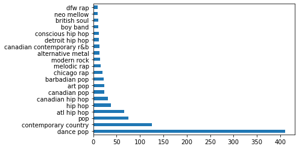

```python
frame['genre'].value_counts()[:20].plot(kind='barh')
```

Unsurprisingly, pop makes it to the top. While it appears at first glance that contemporary country is second, there are many subgenres of Hip Hop appearing, such as canadian, atlanta hip hop, and detroit hip hop. This would suggest to our hypothetical artist that they would want to write a song with more of a pop or a hip hop influence. To make sure of this, we can analyze the trends regarding genres within the past year.

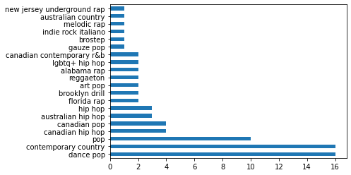

```python
frame[frame.year == 2021]['genre'].value_counts()[:20].plot(kind='barh')
```

To get a better idea of the types of music that are most popular, we can look at the artists that appear the most in the Billboard end of the year list

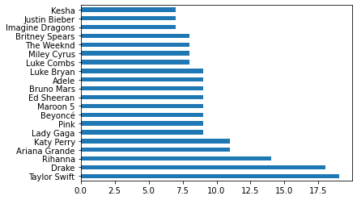

```python
frame['Artist(s)'].value_counts()[:20].plot(kind='barh')
```

```python
frame[frame['Artist(s)'] == "Taylor Swift"]
```

|  | Title | Artist(s) | year | No. | track_ids | artist_ids | amt_features | duration | energy | key | loudness | acousticness | instrumentalness | liveness | valence | tempo | danceability | genre | is_top_20 |
| --- | --- | --- | --- | --- | --- | --- | --- | --- | --- | --- | --- | --- | --- | --- | --- | --- | --- | --- | --- |
| 40 | "Our Song" | Taylor Swift | 2008 | 41.0 | 15DeqWWQB4dcEWzJg15VrN | 06HL4z0CvFAxyc27GXpf02 | 0.0 | 201107 | 0.672 | 2 | 0.0303 | 0.11100 | 0.000000 | 0.3290 | 0.539 | 89.011 | 0.668 | pop | False |
| 47 | "Teardrops on My Guitar" | Taylor Swift | 2008 | 48.0 | 7zMcNqs55Mxer82bvZFkpg | 06HL4z0CvFAxyc27GXpf02 | 0.0 | 203040 | 0.417 | 10 | 0.0231 | 0.28800 | 0.000000 | 0.1190 | 0.289 | 99.953 | 0.621 | pop | False |
| 80 | "Love Story" | Taylor Swift | 2008 | 81.0 | 1vrd6UOGamcKNGnSHJQlSt | 06HL4z0CvFAxyc27GXpf02 | 0.0 | 235267 | 0.741 | 2 | 0.0310 | 0.17000 | 0.000000 | 0.0822 | 0.296 | 118.984 | 0.618 | pop | False |
| 108 | "You Belong with Me" | Taylor Swift | 2009 | 11.0 | 3GCL1PydwsLodcpv0Ll1ch | 06HL4z0CvFAxyc27GXpf02 | 0.0 | 231133 | 0.783 | 6 | 0.0386 | 0.16200 | 0.000013 | 0.1140 | 0.443 | 129.964 | 0.687 | pop | True |
| 164 | "White Horse" | Taylor Swift | 2009 | 76.0 | 5YL553x8sHderRBDlm3NM3 | 06HL4z0CvFAxyc27GXpf02 | 0.0 | 234516 | 0.517 | 0 | 0.0486 | 0.36900 | 0.000000 | 0.1770 | 0.366 | 185.262 | 0.423 | pop | False |
| 227 | "Mine" | Taylor Swift | 2010 | 46.0 | 0dBW6ZsW8skfvoRfgeerBF | 06HL4z0CvFAxyc27GXpf02 | 0.0 | 230707 | 0.757 | 7 | 0.0296 | 0.00265 | 0.000002 | 0.1890 | 0.658 | 121.070 | 0.624 | pop | False |
| 259 | "Today Was a Fairytale" | Taylor Swift | 2010 | 84.0 | 2JoJrsEV15OzbijS47lids | 06HL4z0CvFAxyc27GXpf02 | 0.0 | 241822 | 0.779 | 7 | 0.0409 | 0.01350 | 0.000000 | 0.2960 | 0.328 | 158.162 | 0.482 | pop | False |
| 339 | "Back to December" | Taylor Swift | 2011 | 74.0 | 3DrjZArsPsoqbLzUZZV1Id | 06HL4z0CvFAxyc27GXpf02 | 0.0 | 293027 | 0.670 | 2 | 0.0303 | 0.11700 | 0.000000 | 0.3340 | 0.286 | 141.893 | 0.529 | pop | False |
| 376 | "Shake It Off" | Taylor Swift | 2014 | 13.0 | 5xTtaWoae3wi06K5WfVUUH | 06HL4z0CvFAxyc27GXpf02 | 0.0 | 219200 | 0.785 | 7 | 0.1650 | 0.05610 | 0.000000 | 0.1480 | 0.943 | 160.015 | 0.647 | pop | True |
| 470 | "Blank Space" | Taylor Swift | 2015 | 7.0 | 1p80LdxRV74UKvL8gnD7ky | 06HL4z0CvFAxyc27GXpf02 | 0.0 | 231827 | 0.678 | 5 | 0.0644 | 0.08500 | 0.000002 | 0.1300 | 0.583 | 96.006 | 0.753 | pop | True |
| 490 | "Style" | Taylor Swift | 2015 | 29.0 | 1fo2ctLqj3zBhRQKOXprol | 06HL4z0CvFAxyc27GXpf02 | 0.0 | 231000 | 0.791 | 7 | 0.0402 | 0.00245 | 0.002580 | 0.1180 | 0.487 | 94.933 | 0.588 | pop | False |
| 517 | "Wildest Dreams" | Taylor Swift | 2015 | 57.0 | 59HjlYCeBsxdI0fcm3zglw | 06HL4z0CvFAxyc27GXpf02 | 0.0 | 220440 | 0.666 | 8 | 0.0747 | 0.07020 | 0.005930 | 0.1060 | 0.472 | 140.056 | 0.554 | pop | False |
| 678 | "Look What You Made Me Do" | Taylor Swift | 2017 | 39.0 | 1P17dC1amhFzptugyAO7Il | 06HL4z0CvFAxyc27GXpf02 | 0.0 | 211853 | 0.709 | 9 | 0.1230 | 0.20400 | 0.000014 | 0.1260 | 0.506 | 128.070 | 0.766 | pop | False |
| 753 | "Delicate" | Taylor Swift | 2018 | 24.0 | 1Fj0T1XKuhRu7EZzJ7NJIK | 06HL4z0CvFAxyc27GXpf02 | 0.0 | 228461 | 0.447 | 0 | 0.0341 | 0.57700 | 0.000000 | 0.0968 | 0.431 | 90.976 | 0.664 | pop | False |
| 851 | "You Need to Calm Down" | Taylor Swift | 2019 | 39.0 | 6RRNNciQGZEXnqk8SQ9yv5 | 06HL4z0CvFAxyc27GXpf02 | 0.0 | 171360 | 0.671 | 2 | 0.0553 | 0.00929 | 0.000000 | 0.0637 | 0.714 | 85.026 | 0.771 | pop | False |
| 1046 | "Willow" | Taylor Swift | 2021 | 55.0 | 0lx2cLdOt3piJbcaXIV74f | 06HL4z0CvFAxyc27GXpf02 | 0.0 | 214707 | 0.574 | 7 | 0.1700 | 0.83300 | 0.001790 | 0.1450 | 0.529 | 81.112 | 0.392 | pop | False |
| 1120 | "We Are Never Ever Getting Back Together" | Taylor Swift | 2012 | 33.0 | 7AEAGTc8cReDqcbPoY9gwo | 06HL4z0CvFAxyc27GXpf02 | 0.0 | 191880 | 0.676 | 7 | 0.0916 | 0.00957 | 0.000027 | 0.1020 | 0.750 | 85.984 | 0.628 | pop | False |
| 1194 | "I Knew You Were Trouble" | Taylor Swift | 2013 | 16.0 | 6FB3v4YcR57y4tXFcdxI1E | 06HL4z0CvFAxyc27GXpf02 | 0.0 | 219720 | 0.469 | 3 | 0.0363 | 0.00454 | 0.000002 | 0.0335 | 0.679 | 77.019 | 0.622 | pop | True |
| 1237 | "22" | Taylor Swift | 2013 | 71.0 | 6ce41JVa6KFaryfmC2bu2W | 06HL4z0CvFAxyc27GXpf02 | 0.0 | 232120 | 0.729 | 7 | 0.0376 | 0.00215 | 0.001300 | 0.0477 | 0.668 | 103.987 | 0.661 | pop | False |

When particularly focusing on artists that appear most in the top 20 in the end of the year list (because the difference matters a lot to our hypothetical artist, as it does to real artists and labels), we find that the list looks quite different. We start to see slightly newer pop artists such as Olivia Rodrigo, Dua Lipa, and Lorde appear. If we focus on the top artists, Bruno Mars and Rihanna tie for the most amount of occurences in the top 20, which further emphasize that the songs they make, with a pop/R&B type of influence, is what appears to be most popular. However with the vast majority of the artists on there having a pop sound, that would be the genre that our hypothetical artist should aim for.

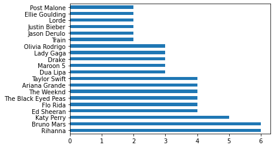

```python
frame['is_top_20'] = frame['No.'] <= 20
top_20 = frame.drop(frame[frame['is_top_20'] == False].index)
top_20['Artist(s)'].value_counts()[:20].plot(kind='barh')
```

Rihanna's End Of Year top 20 appearences

```python
frame[(frame['Artist(s)'] == "Rihanna") & (frame['is_top_20'] == True)]
```

|  | Title | Artist(s) | year | No. | track_ids | artist_ids | amt_features | duration | energy | key | loudness | acousticness | instrumentalness | liveness | valence | tempo | danceability | genre | is_top_20 |
| --- | --- | --- | --- | --- | --- | --- | --- | --- | --- | --- | --- | --- | --- | --- | --- | --- | --- | --- | --- |
| 11 | "Take a Bow" | Rihanna | 2008 | 12.0 | 3goSVuTt3fDYDP6kRnFwuL | 5pKCCKE2ajJHZ9KAiaK11H | 0.0 | 229413 | 0.467 | 9 | 0.0715 | 0.2480 | 0.000000 | 0.0941 | 0.572 | 82.082 | 0.697 | barbadian pop | True |
| 15 | "Disturbia" | Rihanna | 2008 | 16.0 | 2VOomzT6VavJOGBeySqaMc | 5pKCCKE2ajJHZ9KAiaK11H | 0.0 | 238627 | 0.813 | 11 | 0.0571 | 0.0863 | 0.000000 | 0.1680 | 0.722 | 124.921 | 0.707 | barbadian pop | True |
| 16 | "Don't Stop the Music" | Rihanna | 2008 | 17.0 | 0ByMNEPAPpOR5H69DVrTNy | 5pKCCKE2ajJHZ9KAiaK11H | 0.0 | 267080 | 0.669 | 6 | 0.0643 | 0.0336 | 0.000069 | 0.0535 | 0.542 | 122.668 | 0.835 | barbadian pop | True |
| 202 | "Rude Boy" | Rihanna | 2010 | 15.0 | 60jzFy6Nn4M0iD1d94oteF | 5pKCCKE2ajJHZ9KAiaK11H | 0.0 | 222920 | 0.750 | 11 | 0.1270 | 0.1130 | 0.000000 | 0.0788 | 0.812 | 173.906 | 0.563 | barbadian pop | True |
| 285 | "S&M" | Rihanna | 2011 | 12.0 | 7ySUcLPVX7KudhnmNcgY2D | 5pKCCKE2ajJHZ9KAiaK11H | 0.0 | 243600 | 0.684 | 1 | 0.0411 | 0.0105 | 0.000125 | 0.0887 | 0.835 | 127.972 | 0.769 | barbadian pop | True |
| 567 | "Needed Me" | Rihanna | 2016 | 13.0 | 4pAl7FkDMNBsjykPXo91B3 | 5pKCCKE2ajJHZ9KAiaK11H | 0.0 | 191600 | 0.314 | 5 | 0.2440 | 0.1100 | 0.000000 | 0.0825 | 0.296 | 110.898 | 0.671 | barbadian pop | True |

Bruno Mars' End Of Year top 20 appearences

```python
frame[(frame['Artist(s)'] == "Bruno Mars") & (frame['is_top_20'] == True)]
```

|  | Title | Artist(s) | year | No. | track_ids | artist_ids | amt_features | duration | energy | key | loudness | acousticness | instrumentalness | liveness | valence | tempo | danceability | genre | is_top_20 |
| --- | --- | --- | --- | --- | --- | --- | --- | --- | --- | --- | --- | --- | --- | --- | --- | --- | --- | --- | --- |
| 205 | "Just the Way You Are" | Bruno Mars | 2010 | 18.0 | 7BqBn9nzAq8spo5e7cZ0dJ | 0du5cEVh5yTK9QJze8zA0C | 0.0 | 220734 | 0.841 | 5 | 0.0422 | 0.0134 | 0.0 | 0.0622 | 0.424 | 109.021 | 0.635 | dance pop | True |
| 279 | "Grenade" | Bruno Mars | 2011 | 6.0 | 2tJulUYLDKOg9XrtVkMgcJ | 0du5cEVh5yTK9QJze8zA0C | 0.0 | 222091 | 0.558 | 2 | 0.0542 | 0.1480 | 0.0 | 0.1070 | 0.245 | 110.444 | 0.704 | dance pop | True |
| 644 | "That's What I Like" | Bruno Mars | 2017 | 3.0 | 0KKkJNfGyhkQ5aFogxQAPU | 0du5cEVh5yTK9QJze8zA0C | 0.0 | 206693 | 0.560 | 1 | 0.0406 | 0.0130 | 0.0 | 0.0944 | 0.860 | 134.066 | 0.853 | dance pop | True |
| 656 | "24K Magic" | Bruno Mars | 2017 | 16.0 | 6b8Be6ljOzmkOmFslEb23P | 0du5cEVh5yTK9QJze8zA0C | 0.0 | 225983 | 0.803 | 1 | 0.0797 | 0.0340 | 0.0 | 0.1530 | 0.632 | 106.970 | 0.818 | dance pop | True |
| 1189 | "When I Was Your Man" | Bruno Mars | 2013 | 8.0 | 0nJW01T7XtvILxQgC5J7Wh | 0du5cEVh5yTK9QJze8zA0C | 0.0 | 213827 | 0.280 | 0 | 0.0434 | 0.9320 | 0.0 | 0.0880 | 0.387 | 72.795 | 0.612 | dance pop | True |
| 1191 | "Locked Out of Heaven" | Bruno Mars | 2013 | 11.0 | 3w3y8KPTfNeOKPiqUTakBh | 0du5cEVh5yTK9QJze8zA0C | 0.0 | 233478 | 0.698 | 5 | 0.0431 | 0.0490 | 0.0 | 0.3090 | 0.867 | 143.994 | 0.726 | dance pop | True |

```python
frame[(frame['Artist(s)'] == "Adele")]
```

|  | Title | Artist(s) | year | No. | track_ids | artist_ids | amt_features | duration | energy | key | loudness | acousticness | instrumentalness | liveness | valence | tempo | danceability | genre | is_top_20 |
| --- | --- | --- | --- | --- | --- | --- | --- | --- | --- | --- | --- | --- | --- | --- | --- | --- | --- | --- | --- |
| 274 | "Rolling in the Deep" | Adele | 2011 | 1.0 | 1c8gk2PeTE04A1pIDH9YMk | 4dpARuHxo51G3z768sgnrY | 0.0 | 228093 | 0.769 | 8 | 0.0298 | 0.13800 | 0.000000 | 0.0473 | 0.507 | 104.948 | 0.730 | british soul | True |
| 296 | "Someone Like You" | Adele | 2011 | 24.0 | 1zwMYTA5nlNjZxYrvBB2pV | 4dpARuHxo51G3z768sgnrY | 0.0 | 285240 | 0.319 | 9 | 0.0281 | 0.89300 | 0.000000 | 0.0996 | 0.294 | 135.187 | 0.556 | british soul | False |
| 496 | "Hello" | Adele | 2015 | 35.0 | 62PaSfnXSMyLshYJrlTuL3 | 4dpARuHxo51G3z768sgnrY | 0.0 | 295502 | 0.430 | 5 | 0.0305 | 0.33000 | 0.000000 | 0.0854 | 0.288 | 78.991 | 0.578 | british soul | False |
| 578 | "Send My Love (To Your New Lover)" | Adele | 2016 | 26.0 | 0t7fVeEJxO2Xi4H2K5Svc9 | 4dpARuHxo51G3z768sgnrY | 0.0 | 223079 | 0.533 | 6 | 0.0865 | 0.03550 | 0.000003 | 0.1720 | 0.567 | 164.069 | 0.688 | british soul | False |
| 627 | "When We Were Young" | Adele | 2016 | 83.0 | 7GgWAITsYJaRM3r50rfh5w | 4dpARuHxo51G3z768sgnrY | 0.0 | 290900 | 0.595 | 3 | 0.0496 | 0.30300 | 0.000000 | 0.0950 | 0.265 | 144.361 | 0.376 | british soul | False |
| 721 | "Water Under the Bridge" | Adele | 2017 | 88.0 | 4jL6WWKFDqCOPo2hC3VhSS | 4dpARuHxo51G3z768sgnrY | 0.0 | 240439 | 0.833 | 5 | 0.0615 | 0.01420 | 0.000005 | 0.1050 | 0.538 | 94.963 | 0.590 | british soul | False |
| 1101 | "Set Fire to the Rain" | Adele | 2012 | 12.0 | 73CMRj62VK8nUS4ezD2wvi | 4dpARuHxo51G3z768sgnrY | 0.0 | 242974 | 0.670 | 2 | 0.0249 | 0.00408 | 0.000002 | 0.1120 | 0.446 | 107.993 | 0.603 | british soul | True |
| 1129 | "Someone like You" | Adele | 2012 | 43.0 | 1zwMYTA5nlNjZxYrvBB2pV | 4dpARuHxo51G3z768sgnrY | 0.0 | 285240 | 0.319 | 9 | 0.0281 | 0.89300 | 0.000000 | 0.0996 | 0.294 | 135.187 | 0.556 | british soul | False |
| 1148 | "Rumour Has It" | Adele | 2012 | 64.0 | 2A73XBDBQgmdXO8VsXPWIs | 4dpARuHxo51G3z768sgnrY | 0.0 | 223267 | 0.749 | 0 | 0.0446 | 0.61500 | 0.000000 | 0.1670 | 0.574 | 120.052 | 0.612 | british soul | False |

The songs that made it to the top 20, "Rolling In the Deep" and "Set Fire to the Rain" has high energy and low accoustic scores as well, compared to songs with higher accoustic scores like "Someone Like You" or "Rumor Has It". That isn't to say that Adele's music is inherently better or any worse than Bruno Mars' or Rihanna's music, but these numbers can matter to record labels and artists alike, as while there are popular songs, there are profound differences in being #64 and #1 on the Billboard.

Now that we had an overview of the genres and artists that are most popular, and have a broad understanding on how it could assist with our hypothetical artist in creating a song that would appear in the Billboard chart, let's analyze the features of the song and see how that would help them. To do this, I grouped the data by year and averaged out the duration, energy, key, speechiness, acousticness, instrumentalness, liveness, valence,tempo, and danceability.

```python
dfeat = frame.drop(columns=["Title","Artist(s)","No.","track_ids","artist_ids", "genre", "is_top_20"])
dfeat = dfeat.groupby(['year']).mean()
```

```python
dfeat
```

[output not shown]

Suppose our hypothethical artist wants to have a song with high danceability, but wants to analyze how the tempo correlates with it. There appears to be a minimal negative correlation between tempo and danceability as seen in this graph with tempo vs. danceability, suggesting that there are other factors that may impact it but a really high tempo for a danceable track may not be the best idea, as most of the points within the top 20 are clustered at around the 120-140 tempo. It is also notable that the regression line for top 20 songs sits slightly higher than other songs, again suggesting to the artist that a danceable track may be a good idea.

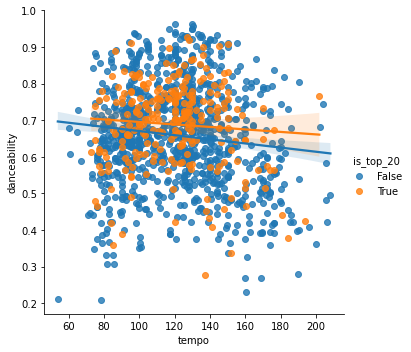

```python
import seaborn as sns

sns.lmplot(data=frame, x="tempo", y="danceability", hue="is_top_20")
```

Now that the hypothetical artist has established a slightly lower tempo and higher danceability in a song, we can look at the valence vs. dancabillity. Valence describes from 0 to 1.0 the musical positiveness conveyed by a track.

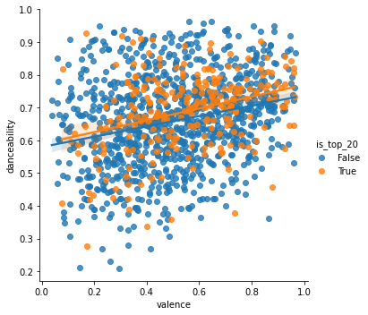

```python
sns.lmplot(data=frame, x="valence", y="danceability", hue="is_top_20")
```

There is a slight positive corelation between valence and danceability. The regression line for top 20 sits slightly higher than the rest of the data suggesting that a song with higher valence wouldn't hurt.

### Suggestions for the hypothetical artist:

Hypothesis: The largest indicator of the popularity of a song, based on the data collected, would have to be the genre and artist. If an artist themselves are popular, the songs that they put out are likely going to be popular too. In addition, the genre may be a great indicator. Dance Pop and Hip Hop are the most popular genres, so I believe that it would be most reflected in the data. I also think that the amt_feature could be a good determinator for whether the song would appear in the top 20, as a lot of songs, particularly nowadays, has a feature. I do not think the majority of the song features, such as duration, energy, and key would be great indicators as to whether or not a song is popular. The duration of a song, while it can artifically increase the amount of streams, doesn't determine the popularity of it. I think the features that could possibly have an impact are danceability and acousticness. The To test this out, I will use a classification algorithm to predict whether a song in the billboard list is top 20 or not.

```python
y = frame['is_top_20']
X = frame.drop(columns=['Title', 'Artist(s)', 'No.', 'track_ids', 'is_top_20'])
```

```python
from sklearn.tree import DecisionTreeClassifier
from sklearn.model_selection import train_test_split

X_train, X_test, y_train, y_test = train_test_split(X, y, test_size = 0.33, random_state = 42)
X_train.shape, X_test.shape
```

```
((845, 14), (417, 14))
```

We will encode the artist ids and genres with numbers, as they are categorical.

```python
import category_encoders as ce

encoder = ce.OrdinalEncoder(cols=['artist_ids', 'genre'])


X_train = encoder.fit_transform(X_train)
X_test = encoder.transform(X_test)
```

I will use the Gini Model for splits

From Kaggle: The Gini index says, if we randomly select two items from a population, they must be of the same class and probability for this is 1 if the population is pure. It works with the categorical target variable “Success” or “Failure”. It performs only binary splits. The higher the value of Gini, higher the homogeneity. CART (Classification and Regression Tree) uses the Gini method to create binary splits.

In addition to prevent overfitting, I set the maximum depth of the tree as 3.

```python
from sklearn.tree import DecisionTreeClassifier
clf_gini = DecisionTreeClassifier(criterion='gini', max_depth=3, random_state=0)

# fit the model
clf_gini.fit(X_train, y_train)
y_pred_gini = clf_gini.predict(X_test)
```

```python
from sklearn.metrics import accuracy_score
from sklearn.metrics import f1_score

print('Model accuracy score with criterion gini index: {0:0.4f}'. format(accuracy_score(y_test, y_pred_gini)))
print(f1_score(y_test, y_pred_gini, average=None))
```

```
Model accuracy score with criterion gini index: 0.8225
[0.90263158 0.        ]
```

[output not shown]

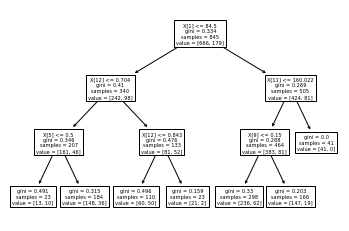

```python
from sklearn import tree
tree.plot_tree(clf_gini.fit(X_train, y_train))
```

### Features on the tree:

```python
X.columns[1], X.columns[12], X.columns[5], X.columns[11], X.columns[9]
```

```
('artist_ids', 'danceability', 'key', 'tempo', 'liveness')
```

### Insights and Conclusion:

At the root of the tree is X[1], which means that the artist is what determines the most upon whether a song is popular or not. The genre does not appear at the tree, which suggests that it is more closely tied to the artist due to the specific genre criteria, such as "canadian pop" ,"neo mellow", or "canadian hip hop" which is likely associated only with the artist Drake. One thing that is surprising is that the amt_features isn't a feature on the tree, as many artists are having more featured artists and collaborations in their tracks. Danceability is also a factor which was predicted, but key, tempo, and liveness are also factors that weren't predicted to be features in the tree. This could be a result of error, as live songs, for instance, can get into the data while searching, a sign of overfitting, or a legitimate factor. Maybe more artists are increasingly trying to get that live sound, like Ai Se Eu Te Pego, or a certain key that the track is in is preferred. Other factors, such as duration and valence aren't features in the tree.

The most important features, according to classification, is the artist making the track themselves, danceability, and tempo. These can be great insights for one trying to understand the general direction music is headed at. This does indicate what is popular, as a wide range of people listen to songs that make them happy and feel good, or feel better. It is also interesting to see how general observations that you kind of notice, such as the overall duration of songs being shorter, and songs being popular due to the fact that the artist themselves are popular, are supported by data. However these insights can be pretty limited as to what makes a song popular. There are many factors that go into the popularity of a song that go beyond the scope of simply the artist themselves, such as with production, songwriters, social influence, and the record label itself. Many songs can be popular because they aren't formulaic, and audiences appreciate that difference. Labels can also play a huge role into what makes music popular. Labels for instance pay radio stations and streamers to push out music, so that in itself is also a strategy that isn't present in the data. In addition, labels can purposefully push out a certain artist more than another. There are also some artists that are very popular within certain genres that isn't reflected on here and could be valuable in future analysis. There can also be limitations with the way that the data has been collected. While I am sure the majority of my data is correct, Spotify Search has the tendency of poducing bad results, so that can also be another factor to note. Finally, artists nowdays are quite versatile, and many expand further than just one genre. Since there was no genre attached to the track, I attached the first genre associated with the artist which isn't always reflective of the song, nor the artist themselves. While this is a great place to start, in the future what I can do to further expand on this data analysis is to include record labels, all writers, producers, and samples attached to the song, and have multiple genres attached to each song to better emphasize the fact that artists are more versatile and work with a wide range of genres. In addition what is existing in the data is one artist attached to each song. Obtaining all of the ArtistIDs can better indicate what songs are popular, as there are occasionally some cases where people listen to a song because of the featuring artist rather than the main artist. In addition, getting analytics of social media influence of artists, especially on TikTok which is changing the landscape of music, can be helpful to incorporate into the data as many popular songs that have made it to the list have been due to the sound going viral on TikTok. Regardless, this analysis provides some general insights into the direction music is headed in due to the frequency of certain genres, artists, and sound features.